# slideshow Fun

## IOSlides

R Markdown is an excellent way to create attractive presentations.

- The finished product is an HTML file so it can be opened in a browser and use the full power of HTML and JavaScript.
- We write reproducible R code that generates a slide show and then we incorporate Shiny to make the presentation interactive.

## HTML5 Presetations

IOSlides is a great way to make HTML5 presentations that display beautifully in the browser using R Markdown. This is just like any other R Markdown file, it’s just a different output type. So lets create a new file and build the YAML header to get started. Control + Shift + N to start a new file. Lets save it. We will call this Slides.Rmd. You probably want to choose a better name. Again, it’s asking us, “Do we want to convert?” We say “yes.”

## YAML Header

Like every other Markdown file, we start with a YAML header, so we give three dashes and close the three dashes. We start with the title. This will be slideshow fun. We give an author, Jared P. Lander. You could put a date, though I generally recommend not to put dates on presentations because you’ll end up reusing it. We set the output to be IOSlides presentation. Since we want to provide additional arguments to IOSlides presentation, it has to go on the next line and be indented. We say IOSlides_presentation, and we are providing more arguments so we put a colon, drop to the next line, and indent again.

## Logo

We can specify a logo to be displayed on the title slide by saying logo: the name of the file. Our file happens to be in the root directory, so we say logo.png. We also want to display our slideshow in widescreen format, and we set it to be self-contained so that way if you want to send someone the slideshow, you only need to send one file, no supporting files. There are other options you can set such as additional CSS, or files to put in the header, but this’ll be good for now. It’s also a good idea to set global options.

## Global Presentation

If you’re giving a presentation to a global audience, you most likely don’t want to be showing the code, so you should set echo equals false. But if this is an instructional presentation, you might want to show the code. There are many other options you might want like cacheing your chunks or centering your images, but for now we’re just going to say echo equals false.

## Global Presentation Setup

We create a new trunk using a snippet, so we type R, then Shift + Tab. We call it setup, and we set include=FALSE because I want neither this code, nor any results to be printed. We say:

`knitr::opts_chunk $set(echo=FALSE)`.

Lets knit the document with `Control + Shift + K`, and see how it looks. We have this nice presentation with our logo in the corner, the title, and the author name. There’s only a title slide for now, but this is a good start to making attractive presentations.

## Build a Full Presentation

With our header and global options set, we can now start adding slides. By default, R Markdown and ioslides use Level Two headings to indicate a new slide. We make our first slide with double hashtags, and we’ll call it Fruit. We use ordinary markdown to generate content. Let’s create a list of fruit. We create a list with a dash and a space, say

- apples, then
- bananas, then
- kiwis.

Let’s knit the document and see how our slideshow works. It looks a little weird because our browser is not expanded, so let’s make it full screen. And we see it says apples, bananas and kiwis. If we use our keyboard to go left, we see our title slide. If we come right, we’re at this slide.

## Widescreen Mode

It’s currently in widescreen mode. We could hit the W key to get out of widescreen, but, thanks to our YAML heading, widescreen is the default. Let’s go ahead and make another slide.

## Graph Slide Preamble

We create the new slide with two hashtags, and we’ll call it Graph Slide. First we need to load data, so let’s make that its own chunk.

We call the chunk Load Data. And here, we will first load the ggplot package, then we will load the diamonds data from within there.

Then in a separate chunk, we will make a histogram. And we will call the chunk hist. It’s a good idea to have your chunks isolated.

Let’s say in the previous chunk, we had to read in a lot of data, and it’s been cached, then the next chunk we plot it.

If we go and change the plot, it’s only going to redo the chunk with plot. But if you’re reading the data and plotting in the same chunk, you change the plot, it has to read in the data all over again.

Same goes for complicated expressions or any operation that might take a while to run, it’s good to have your chunks fairly isolated.

## Graph Slide

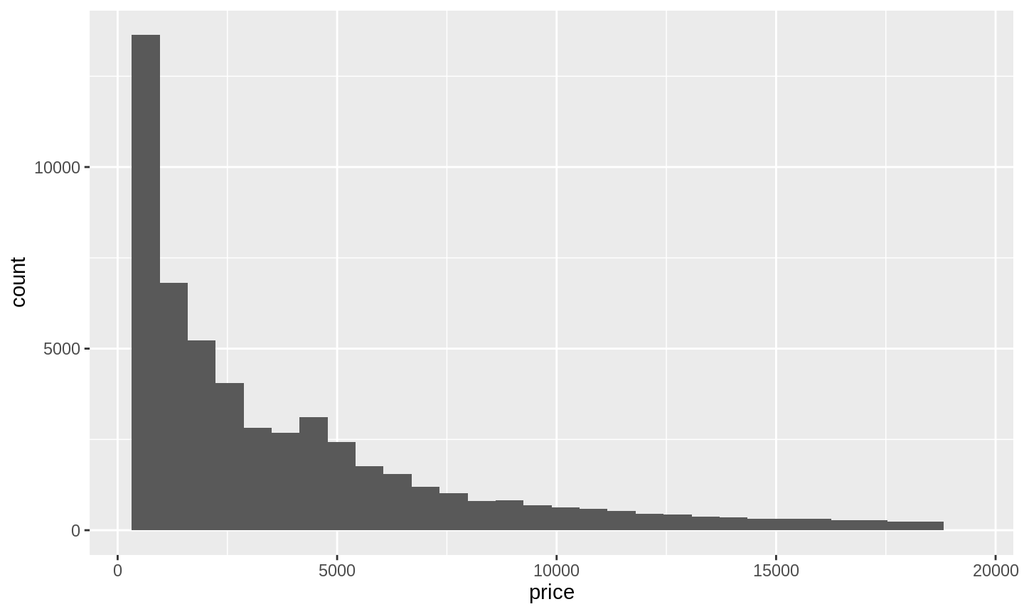

Let’s go ahead and build this histogram. Ggplot with diamonds, aes, x equals price, close both parenthesis, plus geom underscore histogram. Let’s render our document. And we see we have a slide with a plot and with a message ’cause some ggplot functions put out messages. We most likely do not want that message there. So let’s get rid of it. There is a chunk option which says do not show messages. That is simply message equals false. Looking at the document again, and that message no longer appears. Notice, however, our figure is left aligned. We would like it to be centered, so it looks a little more attractive. We come back up to the chunk options and we say fig dot align equals center. Let’s knit the document again. It’s now centered and looks much better. It is really quite easy to make vibrant slideshows using R Markdown. We’ve just scratched the surface and haven’t customized it, but it’s entirely possible to pass in elaborate CSS to make this look like a beautiful presentation. It’s all made simple thanks to R Markdown and ioslides.

## Add Speaker Notes

When giving a presentation, it is often helpful to have speaker notes that you, the speaker, can see on your screen but the audience does not see on their screen. To do this, we will come to the bottom of one of our slides and put a little bit of HTML. You will say div class equals notes.

## Using Shiny in IOSlides

Much like other R Markdown formats, we can set the runtime for this document to be Shiny, That means we can have a slide show advancing one side at a time that has Shiny running and enables us to take advantage of the full power of R all within a slide show. The first step is to go to the YAML header and set the runtime to Shiny. This is on the same level as title, author, and output, so make sure we get the indenting right and that is no indent in this case. We say runtime: shiny.